# Using Silver and Bighead Carp cell lines for the identification of a unique metabolite fingerprint from thiram-specific chemical exposure

Joel G. Putnam, Justine E. Nelson, Eric M. Leis, Richard A. Erickson, Terrance D. Hubert, and Jon J. Amberg

August 5, 2016

## Figures 1

This section of R code collects the data to be graphed.

```r
SVC<-read.csv("SVC thiram data.csv")
BHC<-read.csv("BHC thiram data.csv")
```

This section of code opens all the packages needed to create the graphs.

```r
library(ggplot2)
library(vegan)
library(extrafont)
library(extrafontdb)
library(grid)
library(gridExtra)
```

This section of code adds the Times New Roman font used in the manuscript to the graphs.

```r
loadfonts(device="pdf")
loadfonts(device="win")
choose_font("Times New Roman",quiet=TRUE)
```

```
## [1] "Times New Roman"
```

```r
windowsFonts(times=windowsFont("TT Times New Roman"))
```

This section of code uses the vegan package to perform the distance-based redundancy analysis (dbRDA) using the vegan package. Data is scaled prior to ensure the variance for each m/z ratio is accounted for correctly. The data is considered constrained and the Bray-Curtis distance has been used to complete the analysis.

```r
SVC_pos.1 <- as.data.frame(scale(SVC[,2:1597],center=FALSE))
dbRDA.SVC <- capscale(SVC_pos.1 ~ SVC$level,dist="bray")
```

The scores are collected and used to create a data table:

```r
ggData <- data.frame(scores(dbRDA.SVC)$sites)
ggData$level <- SVC$level
```

Calculation of the principle coordinates (the * 100 is used to convert to percentage):

```r
CAP1svcEig <- round(dbRDA.SVC$CCA$eig[1]/sum(dbRDA.SVC$CCA$eig), 3) * 100
CAP2svcEig <- round(dbRDA.SVC$CCA$eig[2]/sum(dbRDA.SVC$CCA$eig), 3) * 100
```

The graphs to be created need 9 colors to be defined for each treatment level:

```r
cbPalette <- c("#999999", "#000000", "#E69F00", "#56B4E9", "#009E73", "#F0E442", "#0072B2", "#D55E00", "#CC79A7")
```

The summary statistics are calculated for the first two principle coordinates:

```r
ggData2 <- cbind(
  aggregate(ggData$CAP1, by = list(ggData$level), mean),
  aggregate(ggData$CAP2, by = list(ggData$level), mean)$x)
colnames(ggData2) <- c("level", "CAP1", "CAP2")
```

The graph needs text to be defined with font, size, and color

```r
leg.1<-theme(plot.title = element_text(lineheight=.8, face="bold",family="times")) +
  theme(legend.title = element_text(colour="black", size=12, face="bold",family="times")) +
  theme(axis.text=element_text(size=12,face="bold",color="black",family="times"),
        axis.title=element_text(size=12,face="bold",family="times")) +
  theme(plot.title = element_text(family="times", face="bold", colour="black", size=14)) +
  theme(legend.text = element_text(family="times",colour="black", size = 12, face = "bold"))
```

ggplot is used to create the graph. The command “aes” sets the x-axis, y-axis, and each treatment level to a specific color. The command “stat_ellipse” creates the ellipse each treatment base on the first and second principle coordinate. “theme_bw” instructs the graph to show black lines and white empty space. leg.1 has been defined above. xlab and ylab create the axis labels. ggtitle creates the title. scale_fill_manual and scale_color_manual create the legend. geom_point creates the black dot at the center of the ellipse.

```r
SVC.1<-ggplot(data = ggData, aes(x = CAP1, y = CAP2, color = level, fill = level)) +
  stat_ellipse(geom = 'polygon', alpha = 0.5) +
  theme_bw() + leg.1 +
  xlab(paste0("CAP1 (", CAP1svcEig, "% explained)")) +
  ylab(paste0("CAP2 (", CAP2svcEig, "% explained)")) +
  ggtitle("Thiram Treated SVC Fry Cells") +
  scale_fill_manual("Treatment", values = cbPalette) +
  scale_color_manual("Treatment", values = cbPalette) +
  geom_point(data = ggData2, alpha = 1, color = 'black')
```

The same code is applied to the bighead carp data

```r
BHC_pos.1 <- as.data.frame(scale(BHC[,2:700],center=FALSE))
dbRDA.BHC <- capscale(BHC_pos.1 ~ BHC$level,dist="bray")

ggData.BHC <- data.frame(scores(dbRDA.BHC)$sites)
ggData.BHC$level <- BHC$level

CAP1svcEig.BHC <- round(dbRDA.BHC$CCA$eig[1]/sum(dbRDA.BHC$CCA$eig), 3) * 100
CAP2svcEig.BHC <- round(dbRDA.BHC$CCA$eig[2]/sum(dbRDA.BHC$CCA$eig), 3) * 100

ggData2.BHC <- cbind(
  aggregate(ggData.BHC$CAP1, by = list(ggData.BHC$level), mean),
  aggregate(ggData.BHC$CAP2, by = list(ggData.BHC$level), mean)$x)
colnames(ggData2.BHC) <- c("level", "CAP1", "CAP2")

BHC.1<-ggplot(data = ggData.BHC, aes(x = CAP1, y = CAP2, color = level, fill = level)) +
  stat_ellipse(geom = 'polygon', alpha = 0.5) +
  theme_bw() + leg.1 + theme(legend.position="none") +
  xlab(paste0("CAP1 (", CAP1svcEig.BHC, "% explained)")) +
  ylab(paste0("CAP2 (", CAP2svcEig.BHC, "% explained)")) +
  ggtitle("Thiram Treated BHC Fry Cells") +
  scale_fill_manual("Treatment", values = cbPalette) +
  scale_color_manual("Treatment", values = cbPalette) +
  geom_point(data = ggData2.BHC, alpha = 1, color = 'black')
```

Combining the two graphs

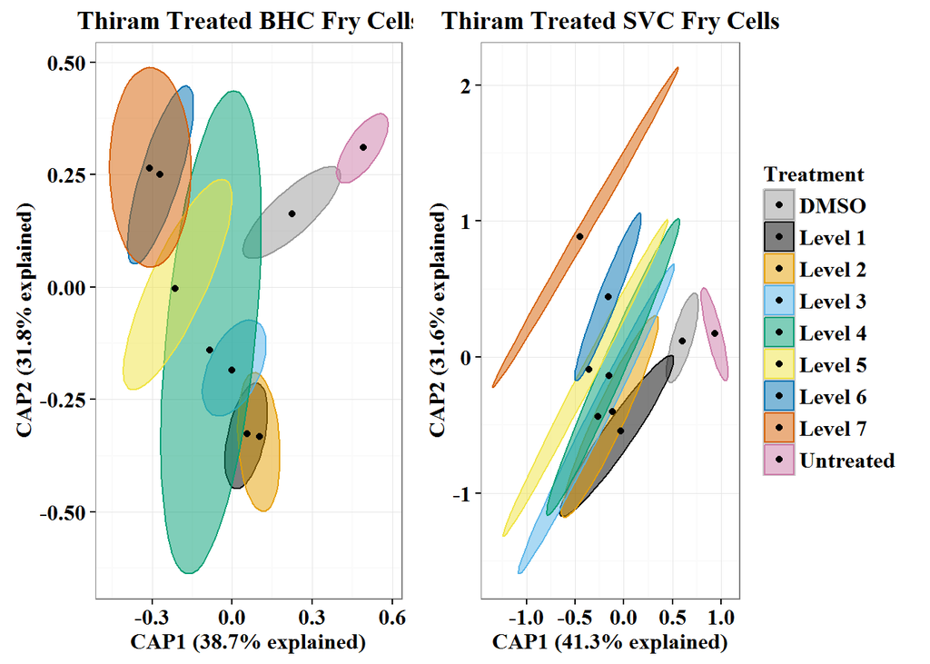

```r
grid.arrange(BHC.1,SVC.1,ncol=2, widths=4:5)
```